# Combining plots using grid and gridExtra

PS239T

01 April, 2020

# Introduction

This document shows how to combine plots in using two sets of packages:

1. `grid` and `gridExtra` packages (see section 3)
2. `patchwork` package (see section 4)

As a rule of thumb, `patchwork` is a newer package and easier to use (it uses syntax similar to ggplot2). The older `gridExtra` package is slightly less intuitive, but may be more flexible, especially when it comes to adding labels to the combined plot.

If you need more help with either set of packages, try the following webpages:

- This vignette shows the many advanced ways `gridExtra` can be used to combine plots and tables: https://cran.r-project.org/web/packages/egg/vignettes/Ecosystem.html.
- This vignette shows the many advanced ways `patchwork` can be used to combine plots: https://gotellilab.github.io/GotelliLabMeetingHacks/NickGotelli/ggplotPatchwork.html.

For example data, it uses Anscombe’s quartet:

- “Anscombe’s quartet comprises four data sets that have nearly identical simple descriptive statistics, yet have very different distributions and appear very different when graphed. Each dataset consists of eleven (x,y) points. They were constructed in 1973 by the statistician Francis Anscombe to demonstrate both the importance of graphing data before analyzing it and the effect of outliers and other influential observations on statistical properties.” ([source: Wikipedia](https://en.wikipedia.org/wiki/Anscombe's_quartet))

Before making our plots, first do a Google image search for Anscombe’s quartet. Our code will try to replicate these plots.

# 1) SET UP

## 1.1. Setup environment

```r
# remove all objects
rm(list=ls())

# check working directory
getwd()
```

```
## [1] "C:/Users/Julia/OneDrive/Documents/Berkeley/2020-01_Spring/PS239T_Spring2020/09_r-analysis-visualization/01_analysis"
```

```r
# Unload all packages
library(pacman)
pacman::p_unload(all)
```

```
## The following packages have been unloaded:
## pacman
```

```r
# Add packages
pacman::p_load(
  tidyverse, #ggplot, dplyr, readr, etc.
  magrittr, #piping
  grid, gridExtra, #combine plots -- option 1
  patchwork, #combine plots -- option 2
  stats, graphics #need for anscombe's quartet data
)
```

```r
# Difficulty downloading patchwork?
pacman::p_load(devtools)
install_github("thomasp85/patchwork")
```

## 1.2. Load data

Anscombe’s quartet is available as a built-in dataset in R.

```r
summary(datasets::anscombe)
```

```
##        x1             x2             x3             x4           y1
##  Min.   : 4.0   Min.   : 4.0   Min.   : 4.0   Min.   : 8   Min.   : 4.260
##  1st Qu.: 6.5   1st Qu.: 6.5   1st Qu.: 6.5   1st Qu.: 8   1st Qu.: 6.315
##  Median : 9.0   Median : 9.0   Median : 9.0   Median : 8   Median : 7.580
##  Mean   : 9.0   Mean   : 9.0   Mean   : 9.0   Mean   : 9   Mean   : 7.501
##  3rd Qu.:11.5   3rd Qu.:11.5   3rd Qu.:11.5   3rd Qu.: 8   3rd Qu.: 8.570
##  Max.   :14.0   Max.   :14.0   Max.   :14.0   Max.   :19   Max.   :10.840
##        y2              y3              y4
##  Min.   :3.100   Min.   : 5.39   Min.   : 5.250
##  1st Qu.:6.695   1st Qu.: 6.25   1st Qu.: 6.170
##  Median :8.140   Median : 7.11   Median : 7.040
##  Mean   :7.501   Mean   : 7.50   Mean   : 7.501
##  3rd Qu.:8.950   3rd Qu.: 7.98   3rd Qu.: 8.190
##  Max.   :9.260   Max.   :12.74   Max.   :12.500
```

## 1.3. Visualization set up

Notice how most Anscombe’s quartet do not have gridlines.

```r
# Change default plot dimensions
knitr::opts_chunk$set(fig.width=6, fig.height=4)

# Load themes
source("../06_setup/visualisation.R")

# Create new theme like theme_ed but without gridlines
theme_jc <- theme_ed +
  theme(panel.grid.major = element_line(color = NA), #no gridlines
        panel.grid.minor = element_line(color = NA))
```

# 2) Create seperate plots

## 2.1. Decide on formatting for single plot

First, try basic scatter plot of x1 and y1 with a fitted line.

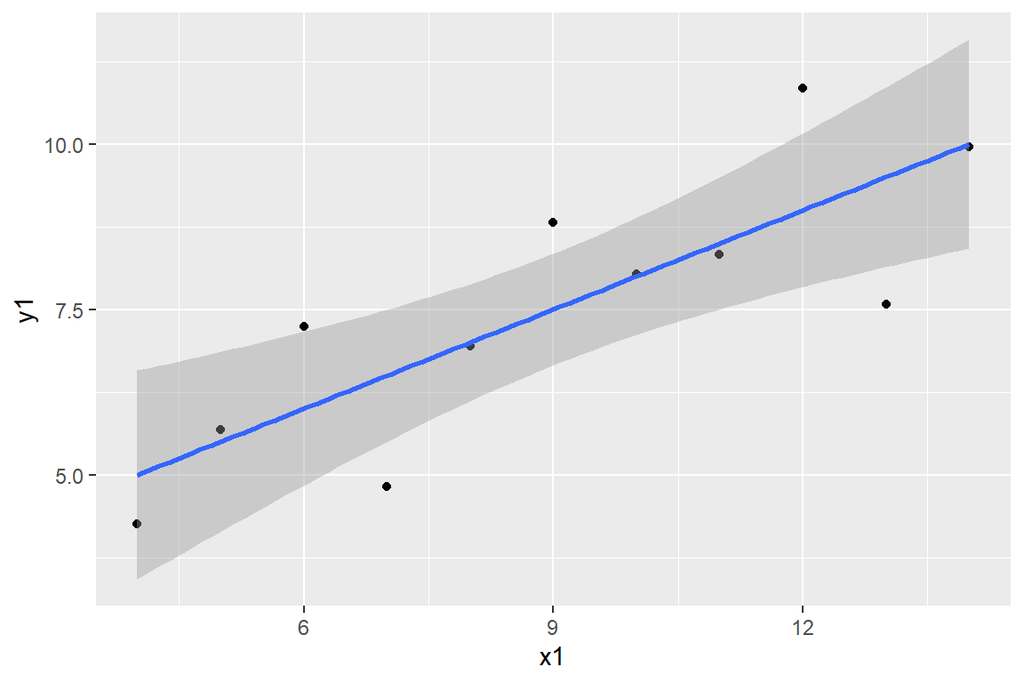

```r
anscombe %>%
  # Set x and y variables
  ggplot(aes(x=x1, y=y1)) +
  # Add points equal to x and y coordinates
  geom_point() +
  # Add OLS smoothing line
  geom_smooth(method='lm')
```

Then make it a little cleaner…

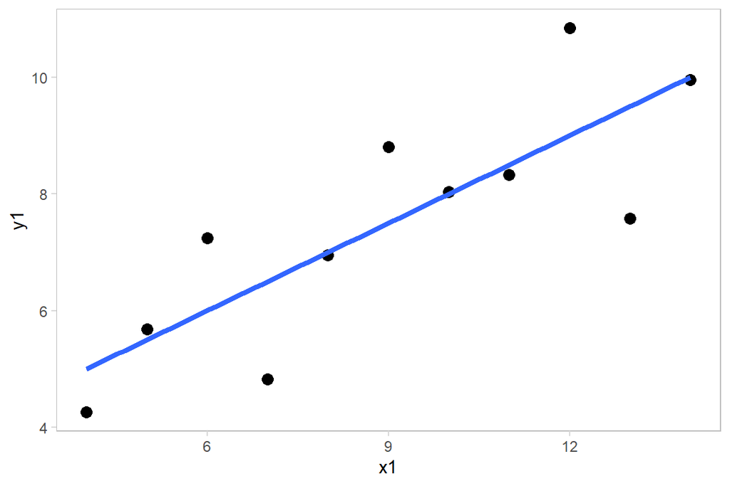

```r
anscombe %>%
  ggplot(aes(x=x1, y=y1)) +
  # Make points bigger using size argument
  geom_point(size=3) +
  # Emphasize fitted lint
  geom_smooth(method='lm',
              se=FALSE, #remove grey CI bands
              size=1.5 #increase line width
              ) +
  # Add theme defined in section 1.3.
  theme_jc
```

## 2.2. Functionalize single plot code

Now, modify the code so that it is a function with two arguments.

1. dat: the dataset to plot (anscome in each case)
2. num: what plot to use; note that variables are labled “x” or “y” then a number (“1”, “2”, “3”, “4”). The function takes a number and generates the corresponding x and y variable names. For example, given num=“2”, the function plots x=“x2” and y=“y2”.

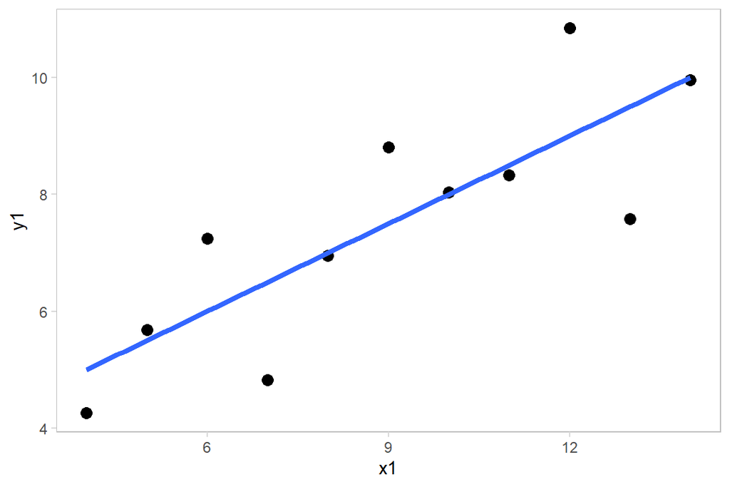

```r
# Create function
gen_plot <- function(dat, num)
{
  dat %>%
    # Set aes (note that we needed string version)
    ggplot(aes_string(x=paste0("x",num),
                      y=paste0("y",num)
                      )) +
    # Add layers using clean formatting from section 2.1.
      geom_point(size=3) +
      geom_smooth(method='lm', se=FALSE, size=1.5) +
      theme_jc
}

# Test plots
gen_plot(anscombe, num=1)
```

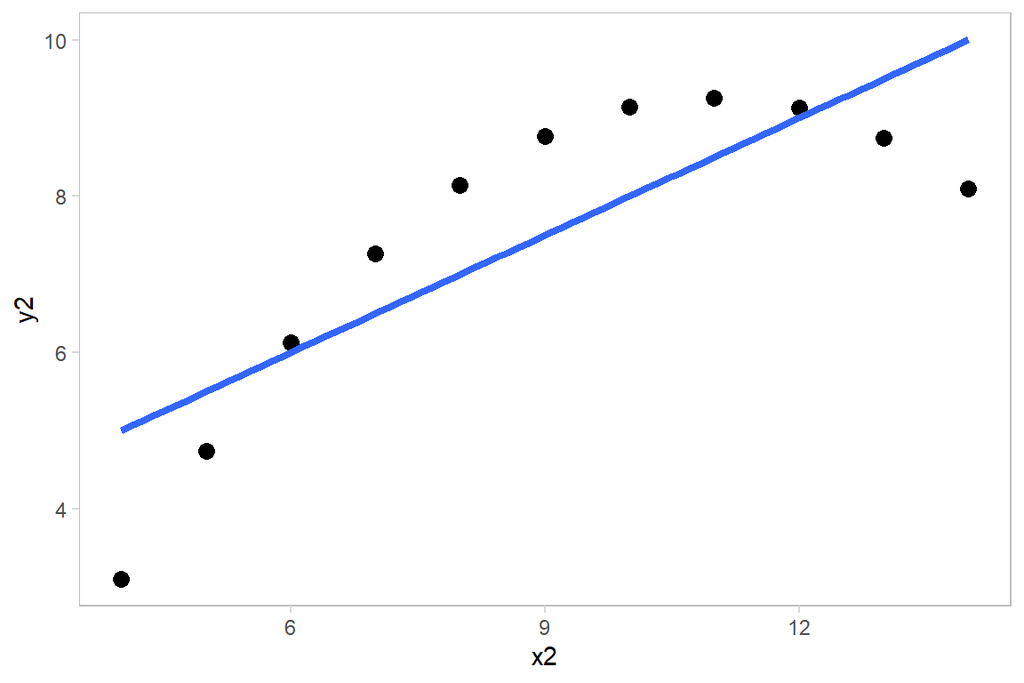

```r
gen_plot(anscombe, num=2)
```

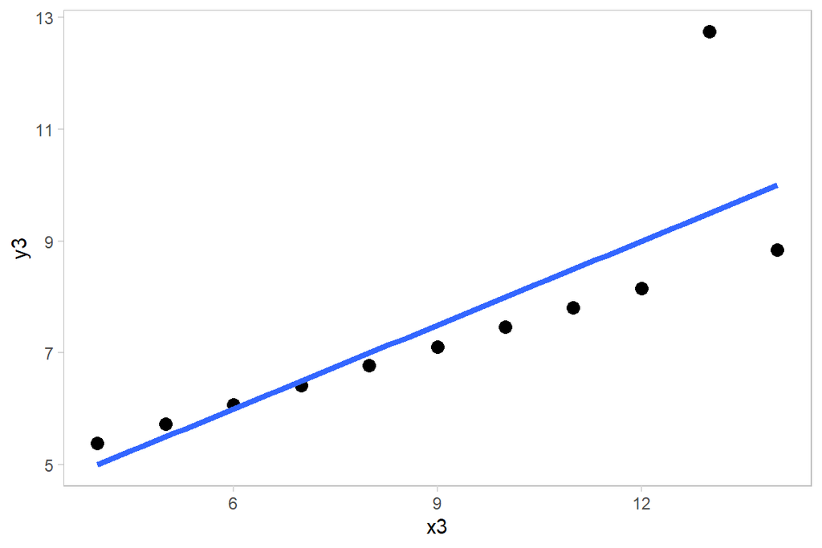

```r
gen_plot(anscombe, num=3)
```

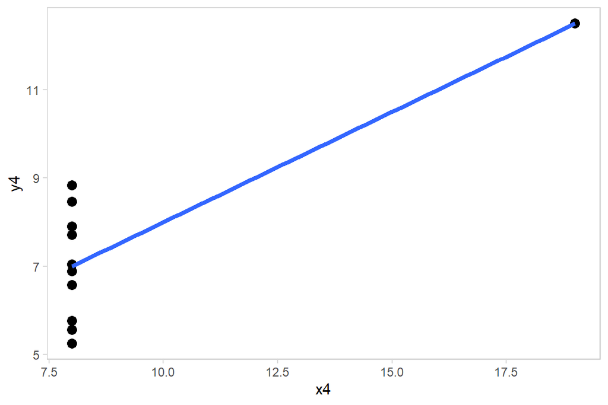

```r
gen_plot(anscombe, num=4)
```

## 2.3. Generate all 4 seperate plots

Save all 4 subplots.

```r
a1 <- gen_plot(anscombe, num=1)
a2 <- gen_plot(anscombe, num=2)
a3 <- gen_plot(anscombe, num=3)
a4 <- gen_plot(anscombe, num=4)
```

# 3) Combine plots: grid and gridExtra

## 3.1. Basic 2x2 Quartet Plot

We can print combined plots using `grid.arrange()`.

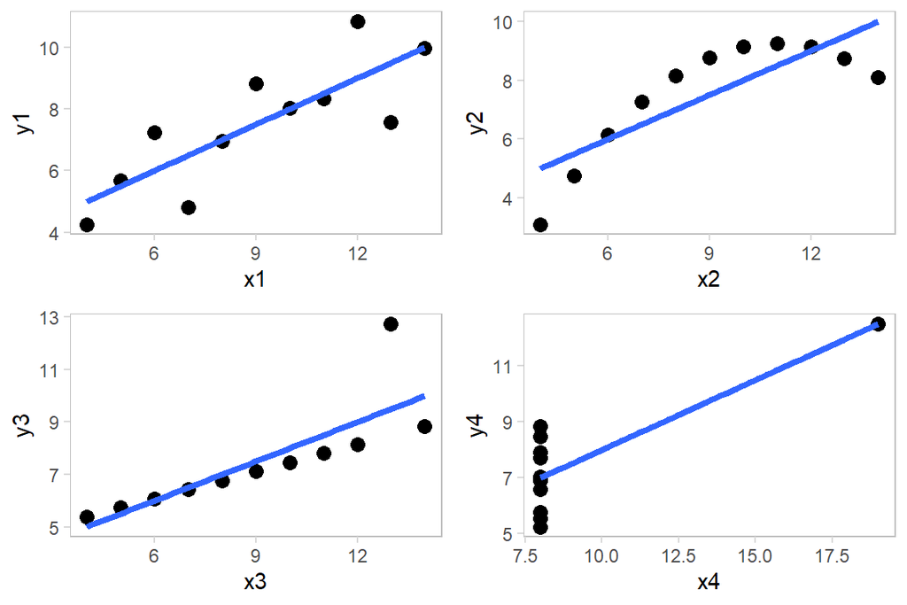

```r
grid.arrange(a1, a2, a3, a4, ncol=2)
```

We can also use `arrangeGrob()` to combine save the combined plots as an object and then print later using `grid.draw()` or `grid.arrange()`.

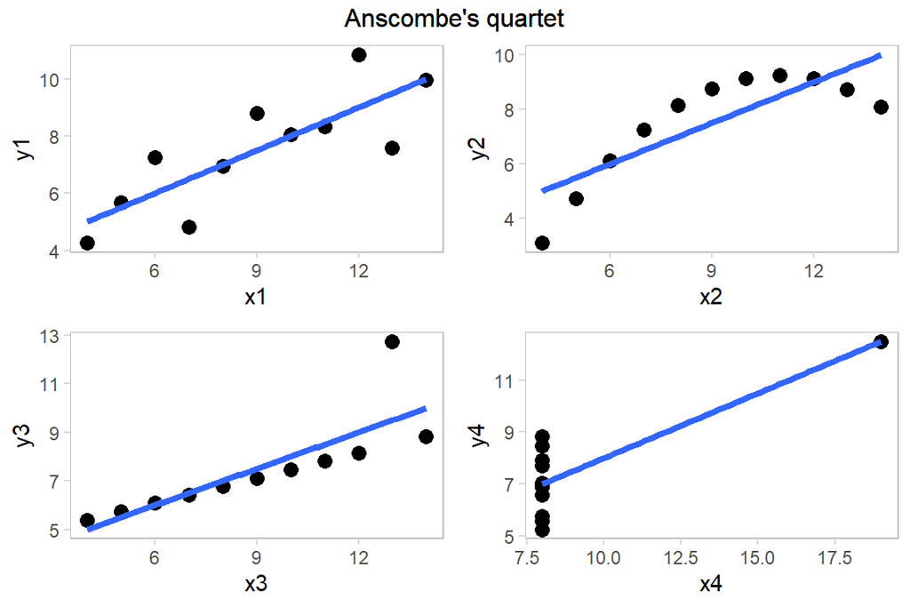

```r
# Create object with combined plot
anscombe_quartet <- arrangeGrob(a1, a2, a3, a4,
  # Two columns
  ncol = 2,
  # Title on top
  top = "Anscombe's quartet")
# Print the grid the screen
grid.arrange(anscombe_quartet)

# Print the grid the screen (alternative function)
grid.draw(anscombe_quartet)
```

Note: If `grid.arrange()` doesn’t work, try `grid.draw()` instead. Check on your computer, but I believe that grid.draw() does not always print in RStudio, but does appear in the knitted document. `grid.arrange()` both prints to screen in RStudio and in the knitted document.

Note that we could have looped through each plot as follows, avoiding unnecessary objects and lines of code.

```r
# Loop through all 4 sets of x and y variables.
p <- map(c(1:4), function(x) gen_plot(anscombe, x))

# Note that we can't use this list as an argument directly
try(grid.arrange(p))
```

```
## Error in gList(structure(list(structure(list(data = structure(list(x1 = c(10,  :
##   only 'grobs' allowed in "gList"
```

```r
try(grid.arrange(unlist(p)))
```

```
## Error in gList(structure(list(data.x11 = 10, data.x12 = 8, data.x13 = 13,  :
##   only 'grobs' allowed in "gList"
```

```r
# Instead, I had to add each element seperately
grid.arrange(p[[1]], p[[2]], p[[3]], p[[4]],
  # Two columns
  ncol = 2,
  # Title on top
  top = "Anscombe's quartet"
  )
```

[output not shown]

## 3.2. Other advanced options for gridExtra

See also http://edrub.in/ARE212/section08.html for great distribution plots using gridExtra.

We can add labels to the combined plot.

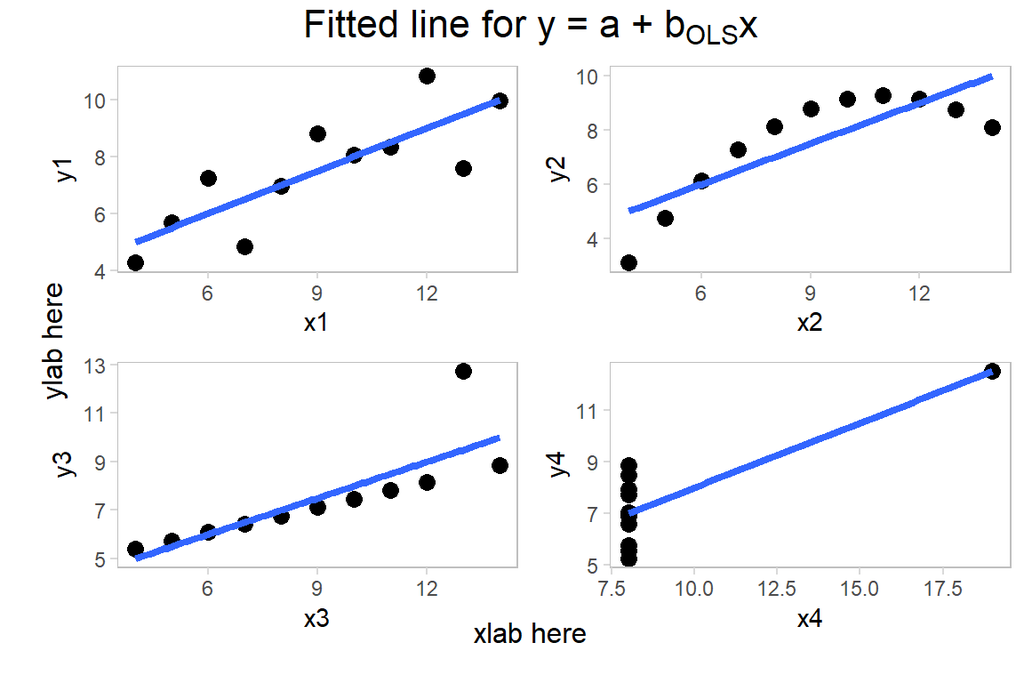

```r
# Create object with combined plot
grid.arrange(a1, a2, a3, a4,
  # Two columns
  ncol = 2,
  # Title on top
  top = textGrob(expression(paste(
    "Fitted line for y = a + ", b[OLS], "x")),
    gp = gpar(fontsize = 16, font = 3), check = T),
  # y-axis label
  left = textGrob("ylab here", vjust = 2, rot = 90),
  # x-axis label
  bottom = textGrob("xlab here", vjust = -1)
  )
```

You can also use more complex layouts (see https://cran.r-project.org/web/packages/egg/vignettes/Ecosystem.html for more details).

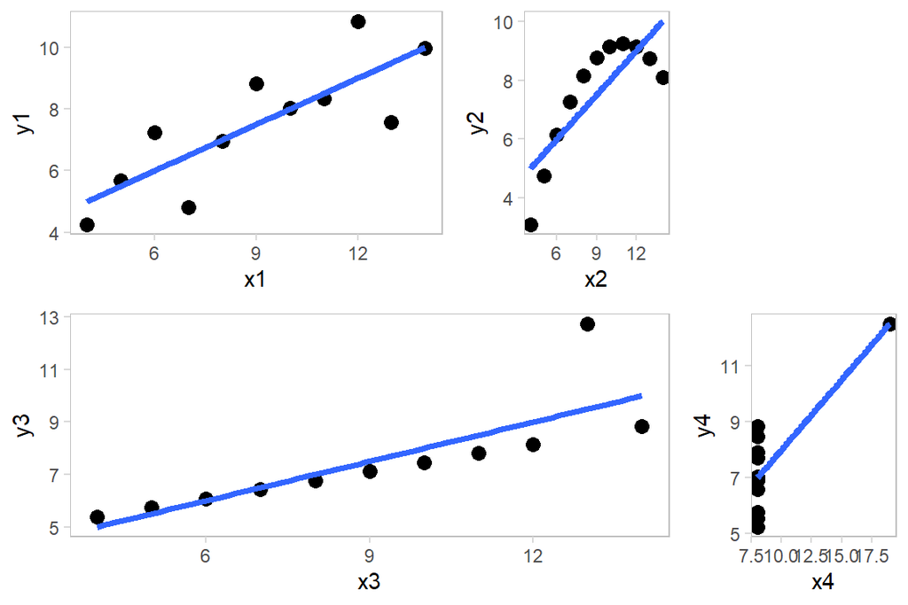

```r
# Create object with combined plot
grid.arrange(a1, a2, a3, a4,
  widths = c(2, 1, 1),
  layout_matrix = rbind(c(1, 2, NA),
                        c(3, 3, 4))
)
```

# 4) Combine plots: patchwork

## 3.1. Basic 2x2 Quartet Plot

With `patchwork`, we use “+” and `plot_layout()` to combine plots.

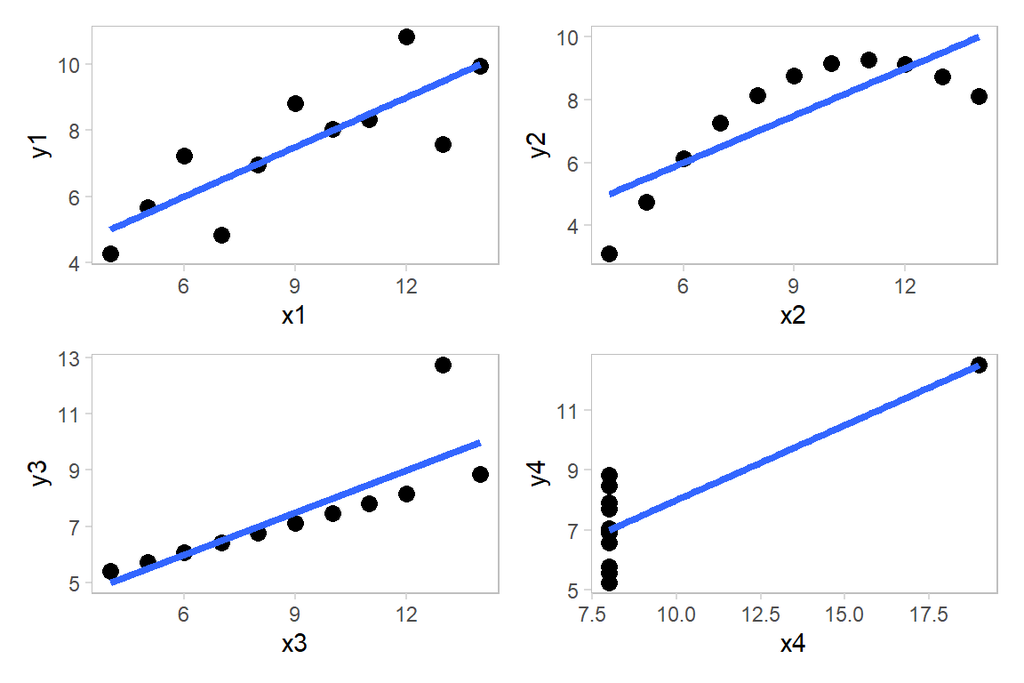

```r
# Default
a1 + a2 + a3 + a4
```

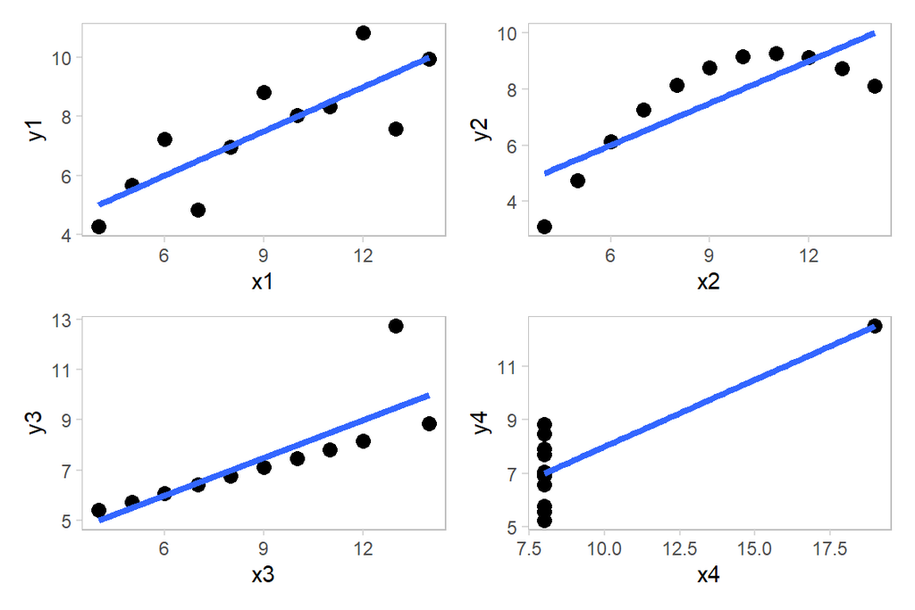

```r
# Force column or row number
a1 + a2 + a3 + a4 + plot_layout(ncol=2, nrow=2)
```

## 3.2. Adding labels

Use `plot_annotation()` and `theme()` functions to add titles/

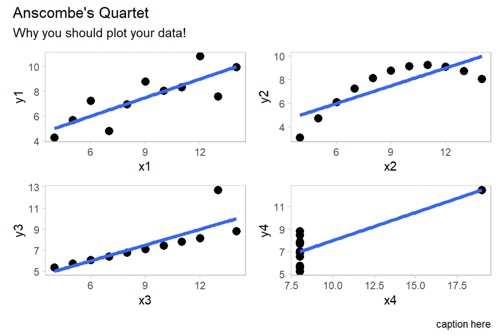

```r
a1 + a2 + a3 + a4 +
  plot_annotation(title = "Anscombe's Quartet",
                  subtitle = 'Why you should plot your data!',
                  caption = 'caption here'
                  )
```

Note that you can also change the theme for the combined plot and subplots using the `&` operator and `theme()` function.

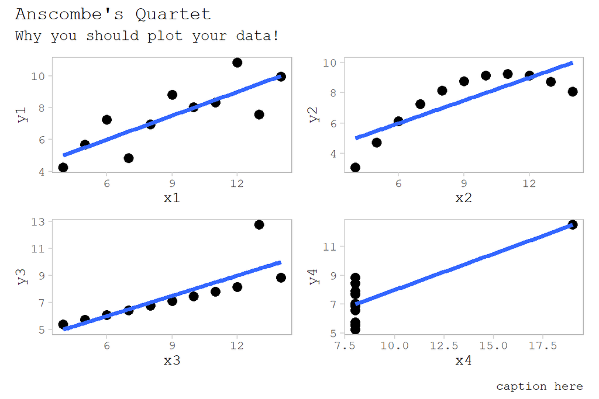

```r
a1 + a2 + a3 + a4 +
  plot_annotation(title = "Anscombe's Quartet",
                  subtitle = 'Why you should plot your data!',
                  caption = 'caption here'
                  ) & #note '&' operator, not '+' operator
  # Change theme for whole plot
  theme(text = element_text('mono'))
```

You can label sub-plots using the tagging argument and `plot_annotation()`.

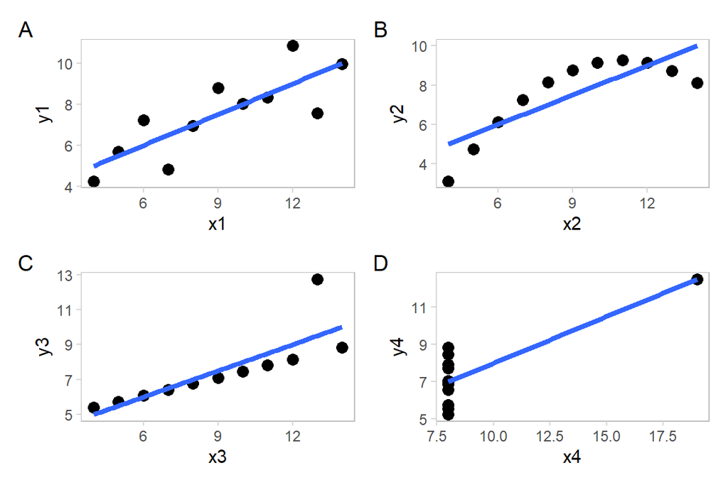

```r
# Simple letter subplot labels
a1 + a2 + a3 + a4 +
  plot_annotation(tag_levels = 'A')
```

Sub-plot labels can also follow more complicated patterns.

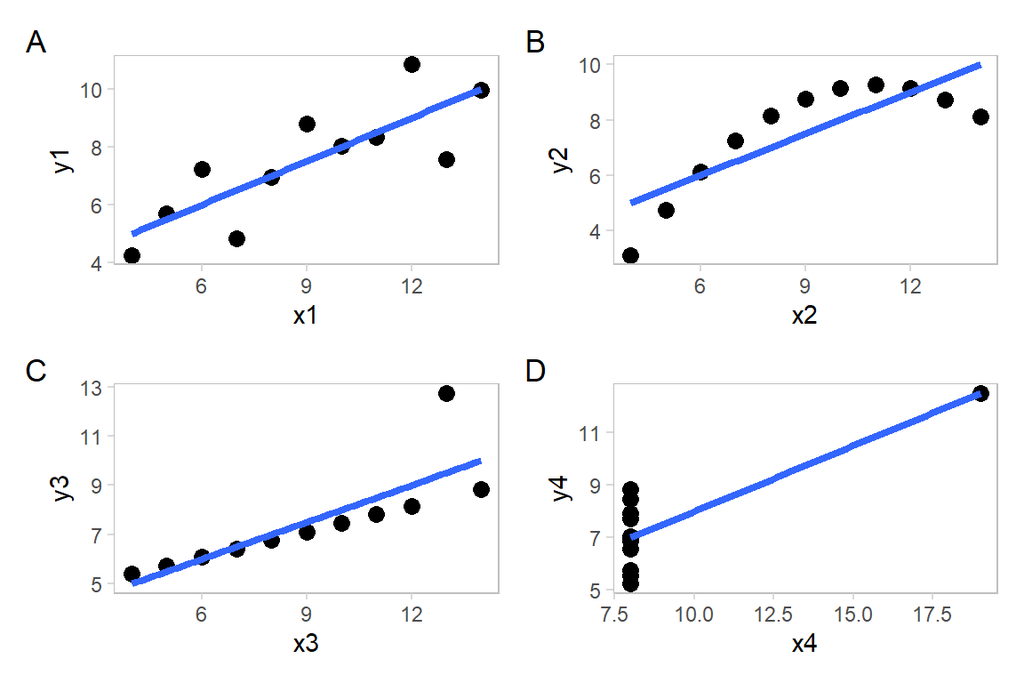

```r
# Simple A# labels
a1 + a2 + a3 + a4 +
  plot_annotation(tag_levels = c('A', '1'))
```

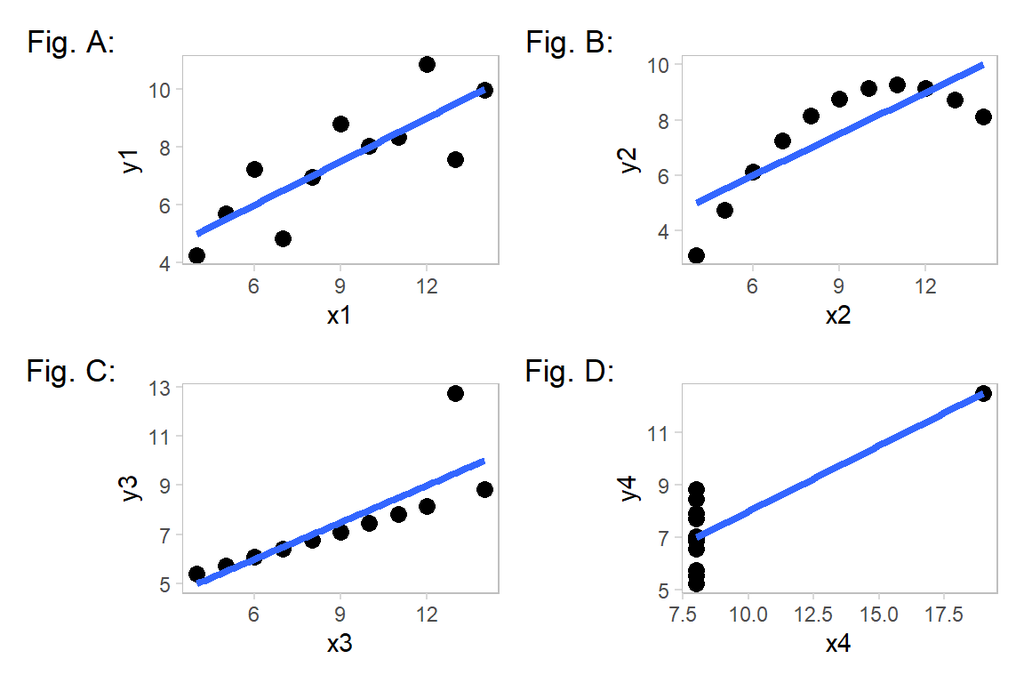

```r
# Complex labels
a1 + a2 + a3 + a4 +
  plot_annotation(tag_levels = c('A', '1'),
                  tag_prefix = 'Fig. ',
                  tag_sep = '.', tag_suffix = ':')
```

The font/size of labels adjusted using the ‘&’ operator and the plot.tag argument for the theme() function

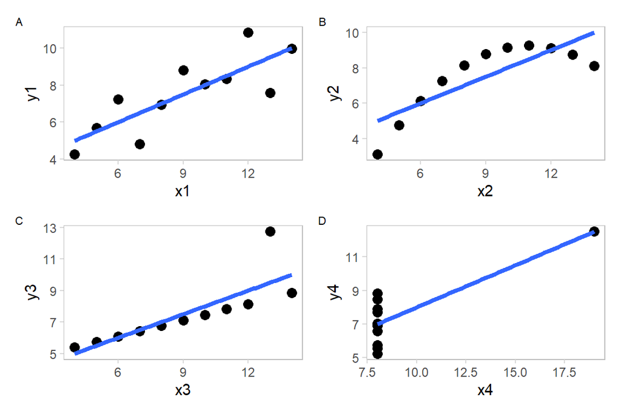

```r
# Make font smaller
a1 + a2 + a3 + a4 +
  plot_annotation(tag_levels = 'A') &
  theme(plot.tag = element_text(size = 8))
```

## 3.3. Intuitive layouts

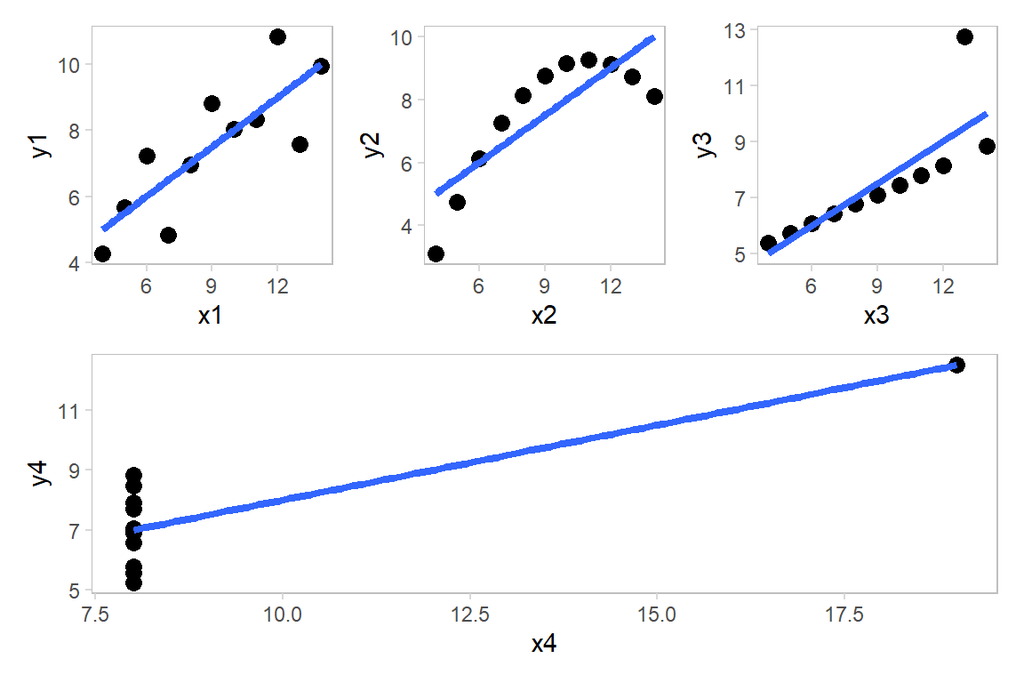

```r
# Example 1
(a1 | a2 | a3) /
  a4
```

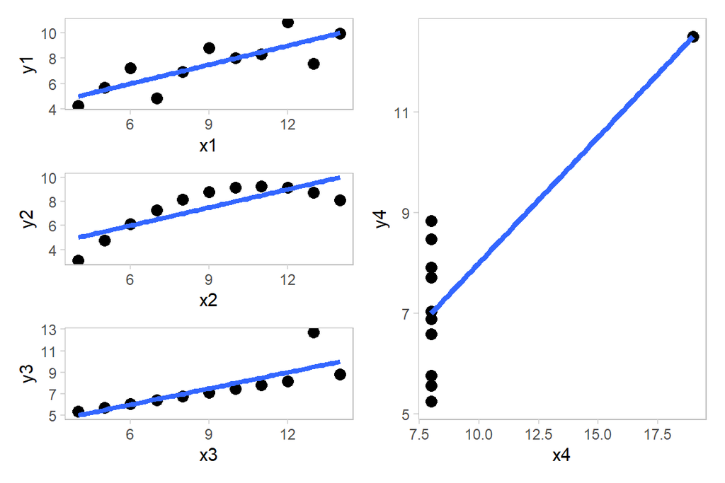

```r
# Example 2
(a1 /
 a2 /
 a3)  | a4
```

The `patchwork` vignette also outlines how to use another syntax that it calls nested layouts. Since it is more complicated and less intutive, I have not included it in this tutorial, but you may want to look at the package documentation further if the intuitive layout in this section does not meet your needs.

## 3.4. Other advanced options for patchwork

We can change the relative widths of each plot:

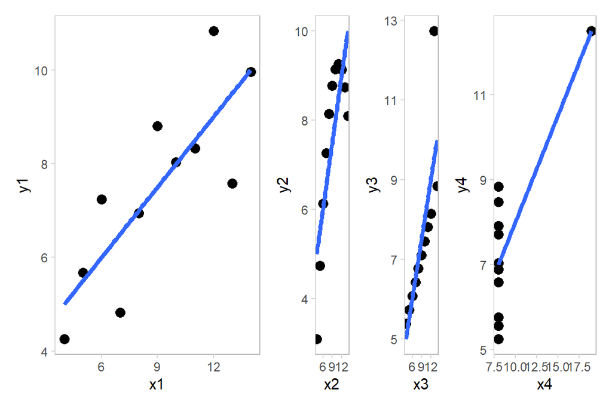

```r
a1 + a2 + a3 + a4 + plot_layout(nrow=1, widths=c(6,1,1,3))
```

Or add a spacer plot:

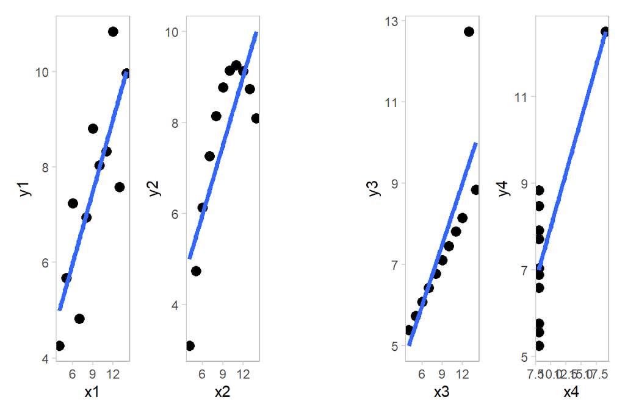

```r
a1 + a2 + plot_spacer() + a3 + a4 + plot_layout(nrow=1)
```

Lastly, the `-` operator can be used for subtrack placement.

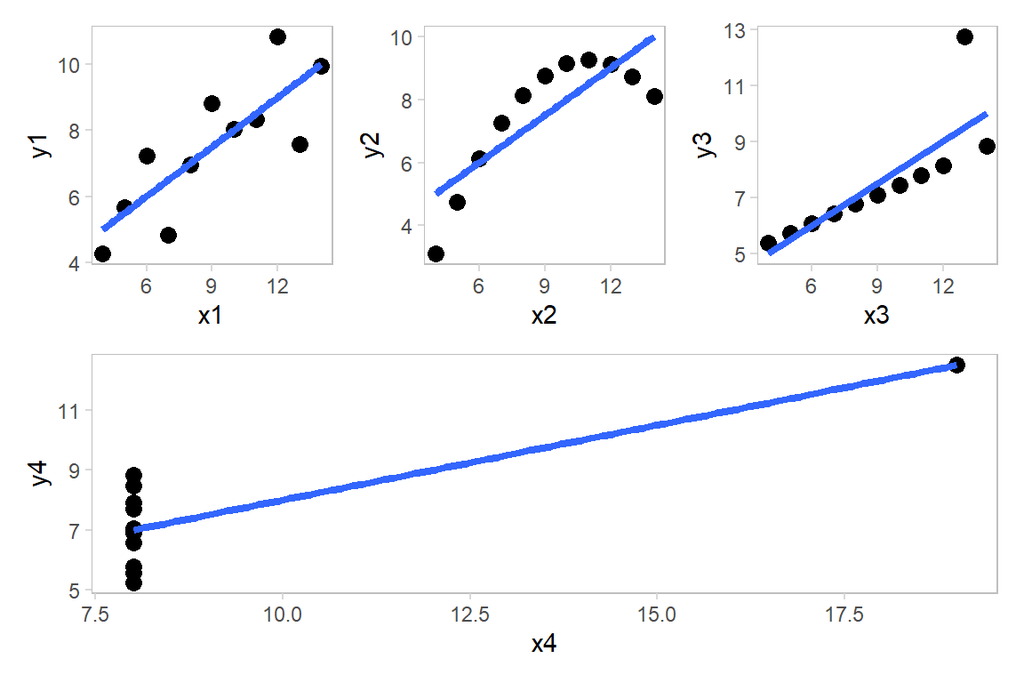

```r
a1 + a2 + a3 - a4 + plot_layout(ncol=1)
```

For more advanced features, see https://www.datanovia.com/en/blog/ggplot-multiple-plots-made-ridiculuous-simple-using-patchwork-r-package/#advanced-features.